# Store Deliveries

Author: Anil Kumar

### 1) Introduction

At the beginning of the COVID lockdown, a local company that facilitates ordering and home delivery of specific products has become inundated with orders. As a result of this increased demand, many orders were being voided by the company’s three participating stores, and there was also an increased volume of deliveries taking longer than the promised 1 hour goal. The company is trying to gain more insight into the factors that contribute to orders getting voided and taking longer to deliver. The data is from a one week period at the start of the COVID lockdown.

### 2) Pre-processing and Cleaning

```r
# Include the necessary libraries
# (not all may be used...but I usually include the most common ones I use by habit)
library(tidyverse)
library(readxl)
library(jtools)
library(plotly)
library(caret)
library(pROC)
library(MLmetrics)
library(janitor)
library(lubridate)
```

```r
#read in the data and clean the column names
df_raw= read_excel("Store_Deliveries2.xlsx", sheet = 1, na='N/A')
df_raw <- df_raw %>% clean_names()
```

```r
#examine dataset
glimpse(df_raw)
```

```
## Rows: 2,320
## Columns: 10
## $ retailer_id              <dbl> 1, 1, 1, 1, 1, 1, 1, 1, 1, 1, 1, 1, 1, 1, 1, ~
## $ delivery_neighborhood_id <dbl> 1, 1, 1, 1, 1, 1, 1, 1, 1, 1, 1, 1, 1, 1, 1, ~
## $ order_id                 <chr> "11-00011", "11-00012", "11-00013", "11-00015~
## $ order_date               <dttm> 2020-03-30, 2020-03-30, 2020-03-30, 2020-03-~
## $ order_time               <dttm> 1899-12-31 12:05:00, 1899-12-31 12:17:00, 18~
## $ order_status             <chr> "Delivered", "Delivered", "Delivered", "Deliv~
## $ delivery_time            <dbl> 34, 28, 30, 30, 26, 40, 28, 31, 21, 28, 24, 2~
## $ gmv                      <dbl> 71, 156, 29, 32, 80, 80, 72, 25, 33, 37, 35, ~
## $ delivery_fee             <dbl> 4.99, 4.99, 4.99, 4.99, 4.99, 4.99, 4.99, 4.9~
## $ substitution             <lgl> FALSE, FALSE, FALSE, FALSE, FALSE, TRUE, FALS~
```

```r
#examine individual columns and count the number of missing values
summary(df_raw)
```

```
##   retailer_id    delivery_neighborhood_id   order_id
##  Min.   :1.000   Min.   :1                Length:2320
##  1st Qu.:1.000   1st Qu.:1                Class :character
##  Median :2.000   Median :1                Mode  :character
##  Mean   :1.884   Mean   :1
##  3rd Qu.:3.000   3rd Qu.:1
##  Max.   :3.000   Max.   :1
##
##    order_date                    order_time                  order_status
##  Min.   :2020-03-30 00:00:00   Min.   :1899-12-31 12:00:00   Length:2320
##  1st Qu.:2020-04-02 00:00:00   1st Qu.:1899-12-31 17:09:00   Class :character
##  Median :2020-04-03 00:00:00   Median :1899-12-31 17:55:00   Mode  :character
##  Mean   :2020-04-02 20:42:00   Mean   :1899-12-31 17:41:58
##  3rd Qu.:2020-04-04 00:00:00   3rd Qu.:1899-12-31 18:55:00
##  Max.   :2020-04-05 00:00:00   Max.   :1899-12-31 20:59:00
##
##  delivery_time         gmv          delivery_fee  substitution
##  Min.   : 20.00   Min.   : 20.00   Min.   :4.99   Mode :logical
##  1st Qu.: 36.00   1st Qu.: 36.00   1st Qu.:4.99   FALSE:2157
##  Median : 63.00   Median : 54.00   Median :4.99   TRUE :163
##  Mean   : 77.05   Mean   : 66.36   Mean   :4.99
##  3rd Qu.:109.00   3rd Qu.: 79.00   3rd Qu.:4.99
##  Max.   :234.00   Max.   :250.00   Max.   :4.99
##  NA's   :318
```

```r
sum(is.na(df_raw))
```

```
## [1] 318
```

A few findings from inspecting the summary:

- There are 318 missing values and these are all from the *delivery_time* column
- There is only one value (all 4.99) for the *delivery_fee* column -> this column can be deleted
- There is only one value (all 1) for the *delivery_neighborhood_id* column -> this column can be deleted

Next, the dataset is cleaned prior to analysis and visualization.

```r
data <- df_raw %>%

  # Drop non-predictive variables
  select(-delivery_neighborhood_id, -order_id, -delivery_fee) %>%

  # make retailer_id into factor and rename column
  mutate(retailer_id = factor(retailer_id)) %>%
  mutate(retailer_id = factor(retailer_id, labels=c("Store A","Store B","Store C"))) %>%
  rename(Store = retailer_id) %>%

  # find day of week and label appropriately
  mutate(Day = factor(weekdays(order_date))) %>%
  mutate(Day = factor(Day, levels=c("Monday", "Tuesday","Wednesday",
                                    "Thursday","Friday", "Saturday","Sunday"))) %>%
  select(-order_date) %>% # drop original column as no longer needed

  # turn substitution column into factor and rename
  mutate(substitution = factor(ifelse(substitution==TRUE,
                               "1 or more substitution(s)","No subsitution(s)"))) %>%
  rename(Substitution = substitution) %>%

  # rename GMV column
  rename(GMV = gmv) %>%

  # rename delivery_time column
  rename(Delivery_Time = delivery_time) %>%

  # make order_status into factor
  mutate(order_status = factor(order_status)) %>%
  rename(Order_Status = order_status) %>%

  # Parse hour of order_time and label appropriately
  mutate(Hour = factor(substring(as.character(order_time),12,13))) %>%
  mutate(Hour = factor(Hour, labels=c("12pm", "1pm","2pm","3pm","4pm",
                                      "5pm","6pm","7pm","8pm"))) %>%
  select(-order_time) %>% # drop original column as no longer needed

  # Binarize Hour variable into before or after 5pm
  mutate(Time_of_Day = ifelse(Hour %in% c('12pm','1pm','2pm','3pm','4pm'),
                                         "Earlier than 5pm","Later than 5pm")) %>%

  # create column for past 1hr delivery
  mutate(Delivery_Over_1hr = factor(ifelse(Delivery_Time > 60,"Over 1hr", "1hr or less"))) %>%

  # create column for weekday vs. weekend
  mutate(Weekend = factor(ifelse(Day %in% c('Saturday','Sunday','Friday'),
                                           "Weekend","Non-Weekend")))
```

The data is re-examined to check that cleaning was performed appropriately.

```r
summary(data)
```

```
##      Store        Order_Status  Delivery_Time         GMV
##  Store A:921   Delivered:2002   Min.   : 20.00   Min.   : 20.00
##  Store B:746   Void     : 318   1st Qu.: 36.00   1st Qu.: 36.00
##  Store C:653                    Median : 63.00   Median : 54.00
##                                 Mean   : 77.05   Mean   : 66.36
##                                 3rd Qu.:109.00   3rd Qu.: 79.00
##                                 Max.   :234.00   Max.   :250.00
##                                 NA's   :318
##                     Substitution         Day           Hour
##  1 or more substitution(s): 163   Monday   :183   5pm    :746
##  No subsitution(s)        :2157   Tuesday  :170   6pm    :579
##                                   Wednesday:179   7pm    :345
##                                   Thursday :219   8pm    :188
##                                   Friday   :481   4pm    :143
##                                   Saturday :676   12pm   :111
##                                   Sunday   :412   (Other):208
##  Time_of_Day          Delivery_Over_1hr        Weekend
##  Length:2320        1hr or less: 965    Non-Weekend: 751
##  Class :character   Over 1hr   :1037    Weekend    :1569
##  Mode  :character   NA's       : 318
##
##
##
##
```

From the above summaries, it is apparent that the missing values are for deliveries that were voided (318 voided orders in total). The 318 missing values for the *Delivery_Over_1hr* and *Delivery_Time* features are due to the fact that these are observations are for voided orders, and therefore don’t have an associated delivery time.

For reference, a summary of the post-cleaning data dictionary is below.

- **Store:** Represents the store; Each store is open daily from 12pm-9pm
- **Order_Status:** *Delivered* = Order was delivered successfully; *Void* = Order was voided (cancelled) by the store; The data does not include orders that were voided by the consumer as this number was negligible
- **Delivery_Time:** The number of minutes between when the order was placed and when the order was delivered
- **GMV (Gross Merchandise Value):** the dollar value of the order
- **Substitution:** Whether the retailer substituted at least one item on the order due to availability
- **Day:** Day of week the order was placed
- **Weekend:** Whether the order was placed on a weekend or non-weekend
- **Hour:** Hour the order was placed (12pm = 12:00pm-12:59pm; 1pm = 1:00pm-1:59pm, etc.)
- **Time_of_Day:** Whether the order was placed before 5pm or after 5pm
- **Delivery_Over_1hr:** Whether the order was delivered in over 1 hour vs. 1 hour or less

### 3) Exploratory Data Analysis

Next, features are visually explored to assess their associations with delivery time and order status. I also created an interactive dashboard using Tableau to assess these relationships. Feel free to use and play around with the dashboard here: https://public.tableau.com/app/profile/anil.kumar8305/viz/OrderDeliveryTimesandVoids/VoidorLate

#### 3a) Exploring Order Status

First, order status is explored in order to examine any trends in the data.  
Of the 2,320 orders, 318 (13.7%) were voided.

```r
data %>% group_by(Order_Status) %>% summarize(count=n()) %>%
         mutate(freq = round(count / sum(count),3))
```

```
## # A tibble: 2 x 3
##   Order_Status count  freq
##   <fct>        <int> <dbl>
## 1 Delivered     2002 0.863
## 2 Void           318 0.137
```

Now, order status is visually explored further with respect to the other features.

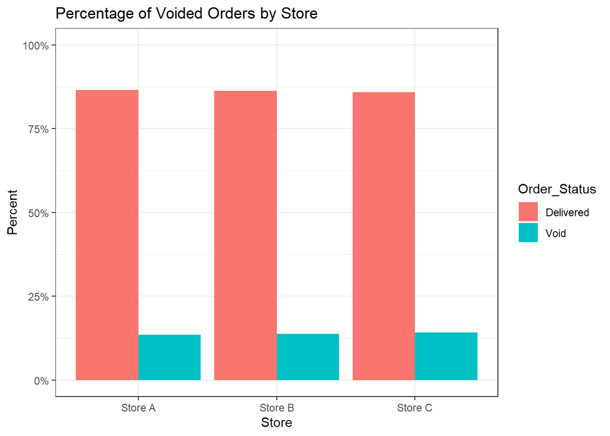

```r
data %>% group_by(Store, Order_Status) %>%
         summarize(count=n()) %>%
         mutate(Percent = round(count / sum(count),3)) %>%
         ggplot(aes(x=Store, y=Percent, fill=Order_Status)) + geom_col(position = "dodge") +
         scale_y_continuous(labels = function(x) paste0(x*100, "%"), limits = c(0,1)) +
         ggtitle("Percentage of Voided Orders by Store") +
         theme_bw()
```

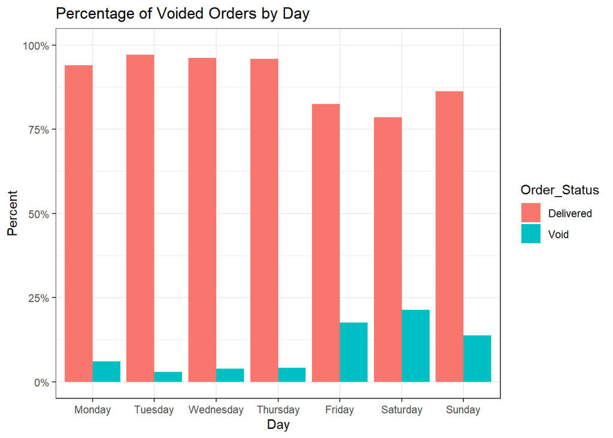

```r
data %>% group_by(Day, Order_Status) %>%
         summarize(count=n()) %>%
         mutate(Percent = round(count / sum(count),3)) %>%
         ggplot(aes(x=Day, y=Percent, fill=Order_Status)) + geom_col(position = "dodge") +
         scale_y_continuous(labels = function(x) paste0(x*100, "%"), limits = c(0,1)) +
         ggtitle("Percentage of Voided Orders by Day") +
         theme_bw()
```

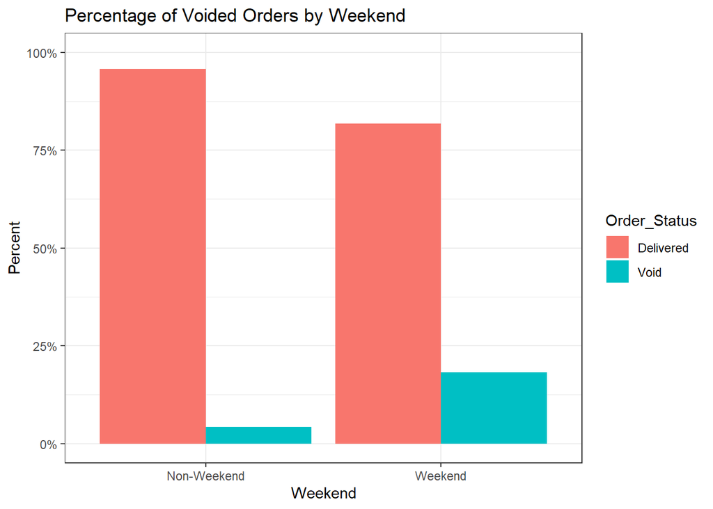

```r
data %>% group_by(Weekend, Order_Status) %>%
         summarize(count=n()) %>%
         mutate(Percent = round(count / sum(count),3)) %>%
         ggplot(aes(x=Weekend, y=Percent, fill=Order_Status)) + geom_col(position = "dodge") +
         scale_y_continuous(labels = function(x) paste0(x*100, "%"), limits = c(0,1)) +
         ggtitle("Percentage of Voided Orders by Weekend") +
         theme_bw()
```

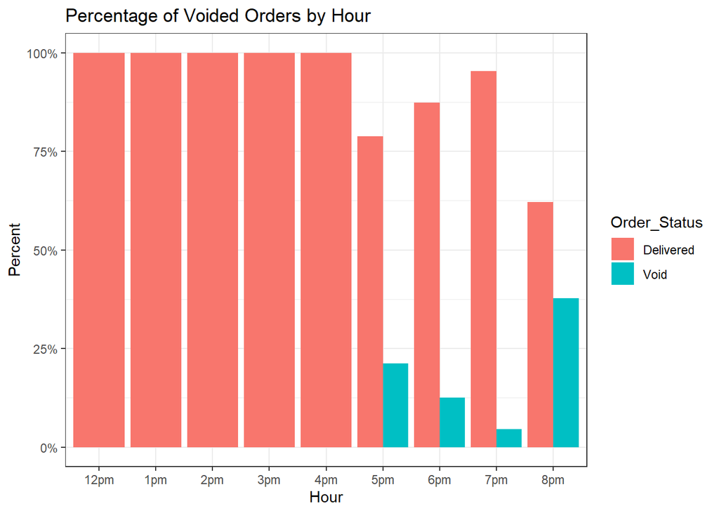

```r
data %>% group_by(Hour, Order_Status) %>%
         summarize(count=n()) %>%
         mutate(Percent = round(count / sum(count),3)) %>%
         ggplot(aes(x=Hour, y=Percent, fill=Order_Status)) + geom_col(position = "dodge") +
         scale_y_continuous(labels = function(x) paste0(x*100, "%"), limits = c(0,1)) +
         ggtitle("Percentage of Voided Orders by Hour") +
         theme_bw()
```

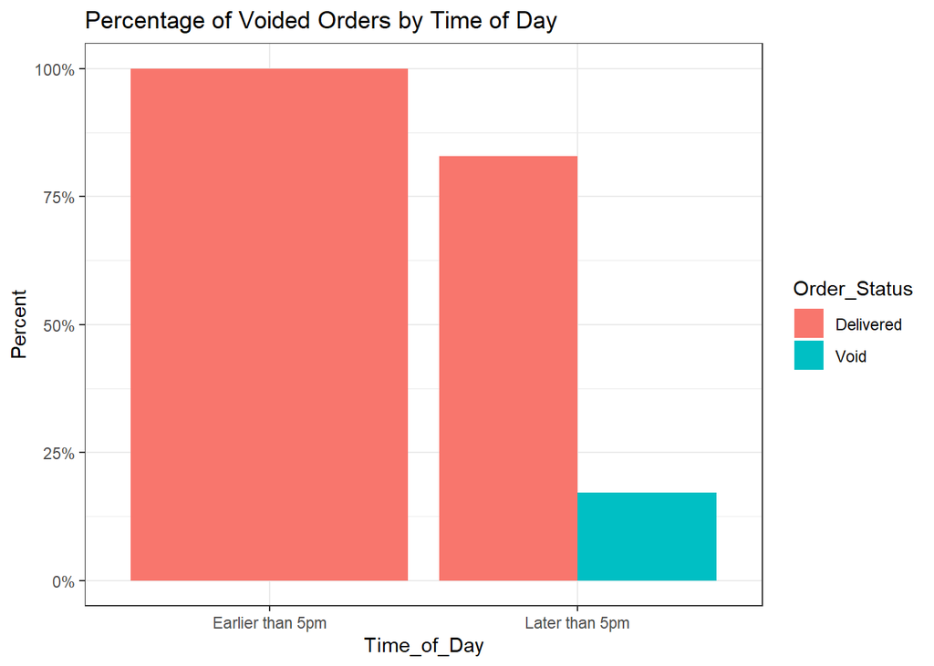

```r
data %>% group_by(Time_of_Day, Order_Status) %>%
         summarize(count=n()) %>%
         mutate(Percent = round(count / sum(count),3)) %>%
         ggplot(aes(x=Time_of_Day, y=Percent, fill=Order_Status)) + geom_col(position = "dodge") +
         scale_y_continuous(labels = function(x) paste0(x*100, "%"), limits = c(0,1)) +
         ggtitle("Percentage of Voided Orders by Time of Day") +
         theme_bw()
```

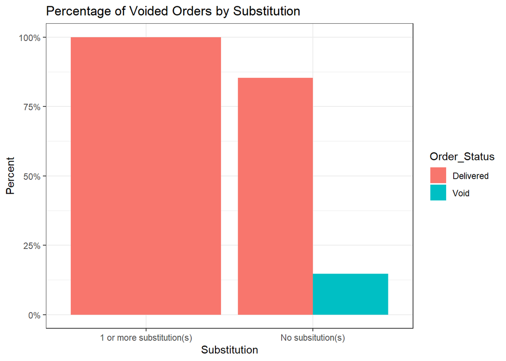

```r
data %>% group_by(Substitution, Order_Status) %>%
         summarize(count=n()) %>%
         mutate(Percent = round(count / sum(count),3)) %>%
         ggplot(aes(x=Substitution, y=Percent, fill=Order_Status)) + geom_col(position = "dodge") +
         scale_y_continuous(labels = function(x) paste0(x*100, "%"), limits = c(0,1)) +
         ggtitle("Percentage of Voided Orders by Substitution") +
         theme_bw()
```

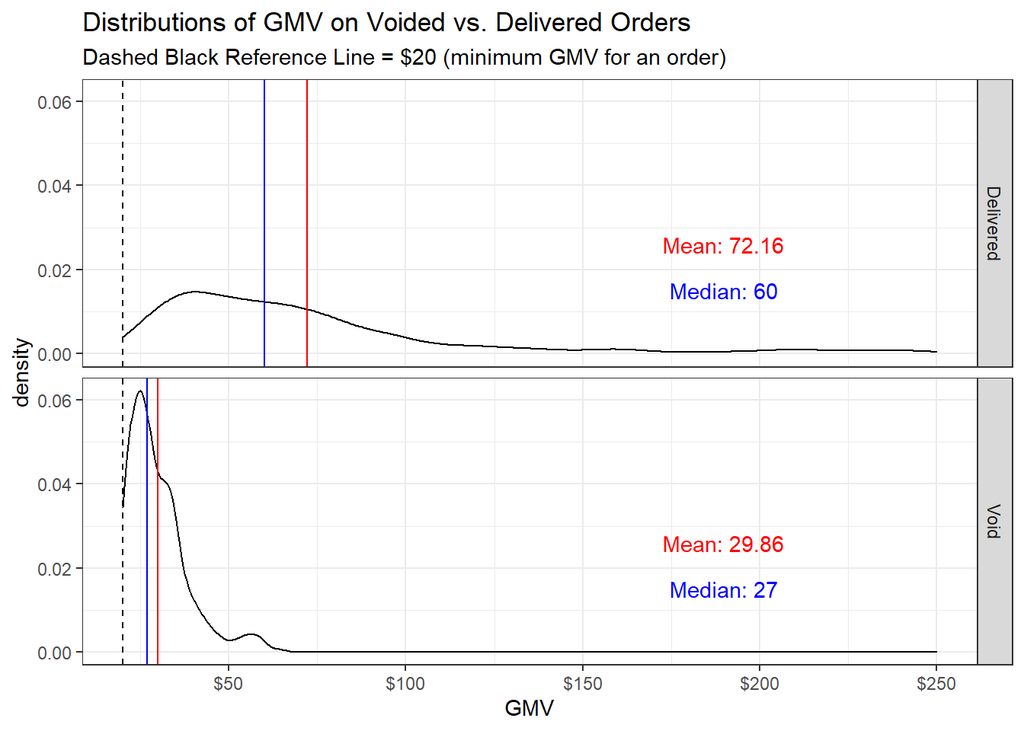

```r
temp <- data %>%  group_by(Order_Status) %>%
        summarize(mean_GMV = round(mean(GMV, na.rm=TRUE),2),
                  median_GMV=round(median(GMV, na.rm=TRUE),2))

data %>% ggplot(.,aes(x=GMV)) + geom_density() + facet_grid(rows=vars(Order_Status)) +
          theme_bw() +
          labs(x="GMV") +
          scale_x_continuous(labels = function(x) paste0("$",x)) +
          geom_vline(aes(xintercept=20), color='black', linetype='dashed') +
          geom_vline(data=temp, aes(xintercept=mean_GMV), color='red') +
          geom_vline(data=temp, aes(xintercept=median_GMV), color='blue') +
          ggtitle("Distributions of GMV on Voided vs. Delivered Orders",
                  subtitle="Dashed Black Reference Line = $20 (minimum GMV for an order)") +
          geom_text(data=temp,aes(x=190, label=paste("Median:",as.character(median_GMV)),
                                  y=0.019), colour="blue",vjust = 1.5)+
          geom_text(data=temp,aes(x=190, label=paste("Mean:",as.character(mean_GMV)),
                                  y=0.03), colour="red",vjust = 1.5)
```

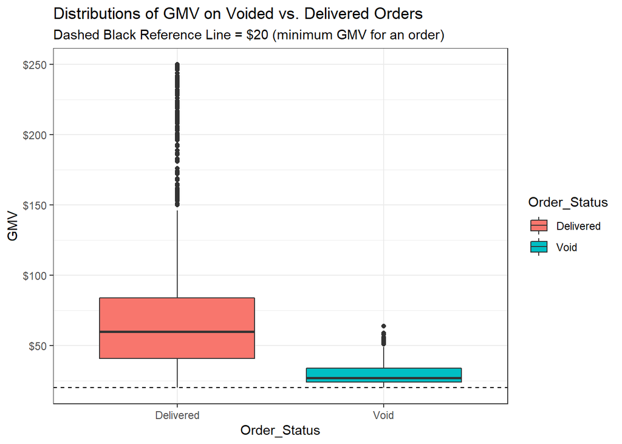

```r
data %>% ggplot(.,aes(x=Order_Status, y=GMV, fill=Order_Status)) + geom_boxplot() +
          scale_y_continuous(labels = function(y) paste0("$",y)) +
          geom_hline(aes(yintercept=20), color='black', linetype='dashed') +
          ggtitle("Distributions of GMV on Voided vs. Delivered Orders",
                  subtitle="Dashed Black Reference Line = $20 (minimum GMV for an order)") +
          theme_bw()
```

There are some interesting trends from the above visualizations.

Voided orders occurred:

- ONLY for orders placed after 5pm
- ONLY for orders where item substitutions were *NOT* permitted
- Mostly on weekends
- Mostly on orders with lower GMV’s

Let’s visually explore the interaction between the *Weekend/Time_of_Day* features and the relationship to *Order_Status*. From the figure below, it’s clear that voided orders *ONLY* occurred after 5pm, and the vast majority were on weekends.

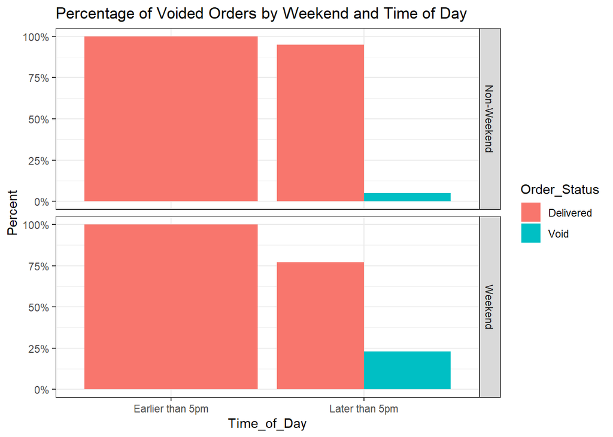

```r
data %>% group_by(Weekend, Time_of_Day, Order_Status) %>%
         summarize(count=n()) %>%
         mutate(Percent = round(count/sum(count),2)) %>%
         ggplot(., aes(x=Time_of_Day,y=Percent, fill=Order_Status)) + geom_col(position = "dodge") +
               scale_y_continuous(labels = function(x) paste0(x*100, "%"), limits = c(0,1)) +
               facet_grid(rows= vars(Weekend)) +
               ggtitle("Percentage of Voided Orders by Weekend and Time of Day") +
               theme_bw()
```

#### 3b) Exploring Delivery Time

Next, delivery time is explored in order to examine any trends in the data.

Of the 2,002 orders that were delivered, 1,037 (51.8%) took over 1 hour to deliver. The median delivery time was 63 minutes and the mean was 77.05 minutes.

```r
data %>% drop_na() %>%
         group_by(Delivery_Over_1hr) %>% summarize(count=n()) %>%
         mutate(freq = round(count / sum(count),3))
```

```
## # A tibble: 2 x 3
##   Delivery_Over_1hr count  freq
##   <fct>             <int> <dbl>
## 1 1hr or less         965 0.482
## 2 Over 1hr           1037 0.518
```

```r
data %>% drop_na() %>%
         summarize(mean_delivery_time=mean(Delivery_Time),
                   median_delivery_time=median(Delivery_Time) )
```

```
## # A tibble: 1 x 2
##   mean_delivery_time median_delivery_time
##                <dbl>                <dbl>
## 1               77.1                   63
```

Now, delivery time is visually explored further with respect to the other features.

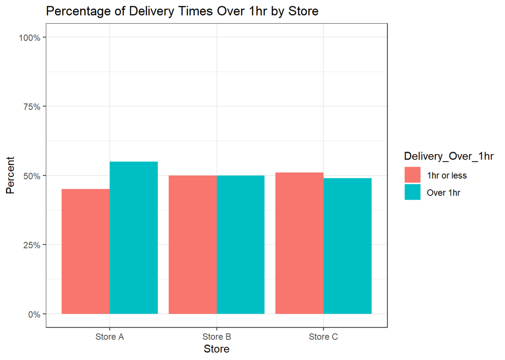

```r
data %>% drop_na() %>%
         group_by(Store, Delivery_Over_1hr) %>%
         summarize(count=n()) %>%
         mutate(Percent = round(count / sum(count),2)) %>%
         ggplot(., aes(x=Store,y=Percent, fill=Delivery_Over_1hr)) + geom_col(position = "dodge") +
         scale_y_continuous(labels = function(x) paste0(x*100, "%"),limits = c(0,1)) +
         ggtitle("Percentage of Delivery Times Over 1hr by Store") +
         theme_bw()
```

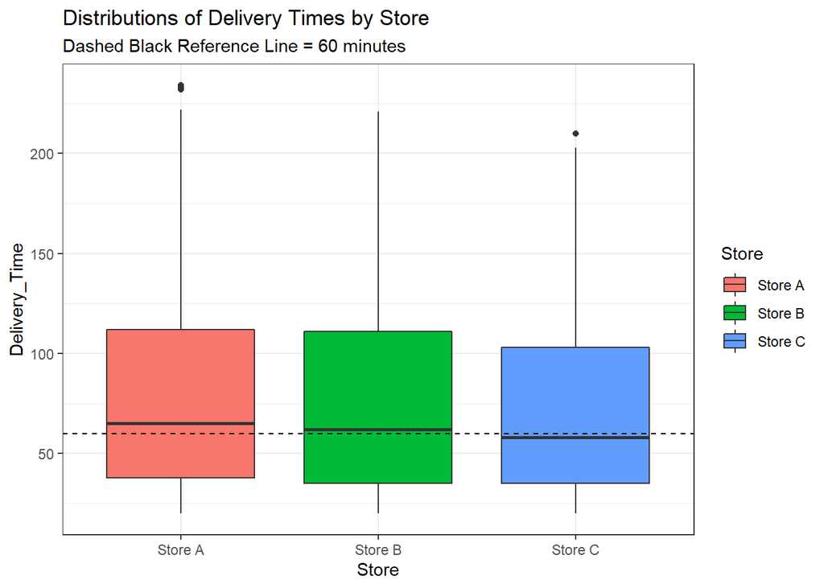

```r
data %>%  drop_na() %>%
          ggplot(.,aes(x=Store, y=Delivery_Time, fill=Store)) +
          geom_boxplot() +
          geom_hline(aes(yintercept=60), color='black', linetype='dashed') +
          ggtitle("Distributions of Delivery Times by Store",
                  subtitle="Dashed Black Reference Line = 60 minutes") +
          theme_bw()
```

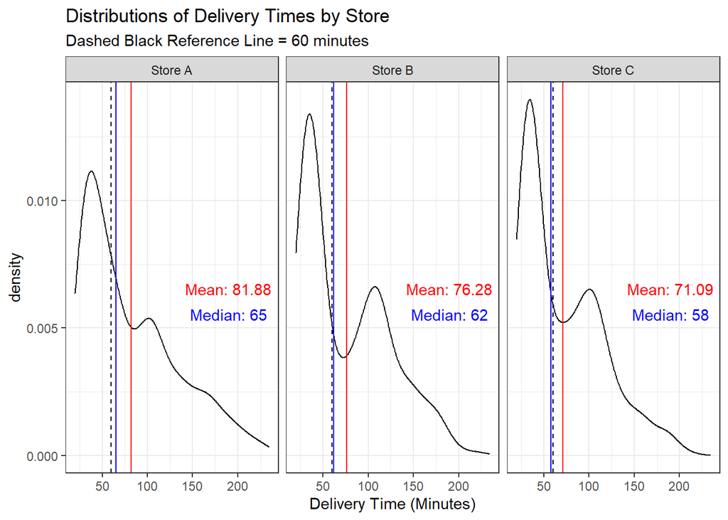

```r
temp <- data %>%  group_by(Store) %>%
        summarize(mean_delivery_time = round(mean(Delivery_Time, na.rm=TRUE),2),
                 median_delivery_time=round(median(Delivery_Time, na.rm=TRUE),2))

data %>% drop_na() %>%
          ggplot(.,aes(x=Delivery_Time)) + geom_density() +
          facet_wrap(~Store) +
          theme_bw() +
          labs(x="Delivery Time (Minutes)") +
          geom_vline(aes(xintercept=60), color='black', linetype='dashed') +
          geom_vline(data=temp, aes(xintercept=mean_delivery_time), color='red') +
          geom_vline(data=temp, aes(xintercept=median_delivery_time), color='blue') +
          ggtitle("Distributions of Delivery Times by Store",
                  subtitle="Dashed Black Reference Line = 60 minutes") +
          geom_text(data=temp,aes(x=190, label=paste("Median:",as.character(median_delivery_time)),
                                  y=0.006), colour="blue",vjust = 1.5)+
          geom_text(data=temp,aes(x=190, label=paste("Mean:",as.character(mean_delivery_time)),
                                  y=0.007), colour="red",vjust = 1.5)
```

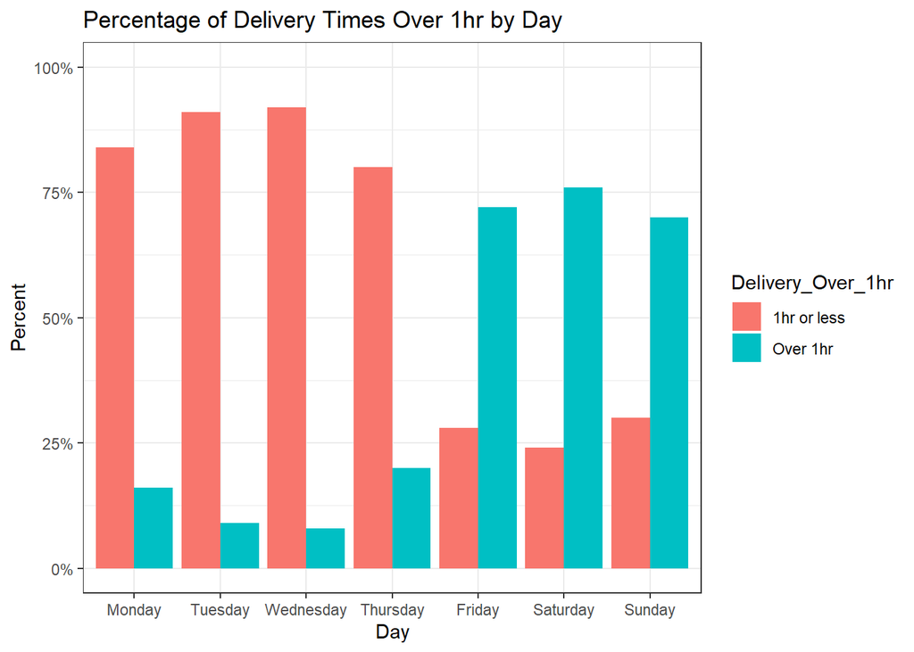

```r
data %>% drop_na() %>%
         group_by(Day, Delivery_Over_1hr) %>%
         summarize(count=n()) %>%
         mutate(Percent = round(count / sum(count),2)) %>%
         ggplot(., aes(x=Day,y=Percent, fill=Delivery_Over_1hr)) + geom_col(position = "dodge") +
         scale_y_continuous(labels = function(x) paste0(x*100, "%"), limits = c(0,1)) +
         ggtitle("Percentage of Delivery Times Over 1hr by Day") +
         theme_bw()
```

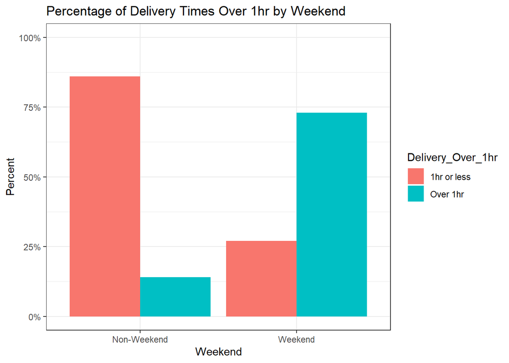

```r
data %>% drop_na() %>%
         group_by(Weekend, Delivery_Over_1hr) %>%
         summarize(count=n()) %>%
         mutate(Percent = round(count / sum(count),2)) %>%
         ggplot(., aes(x=Weekend,y=Percent, fill=Delivery_Over_1hr)) + geom_col(position = "dodge") +
         scale_y_continuous(labels = function(x) paste0(x*100, "%"), limits = c(0,1)) +
         ggtitle("Percentage of Delivery Times Over 1hr by Weekend") +
         theme_bw()
```

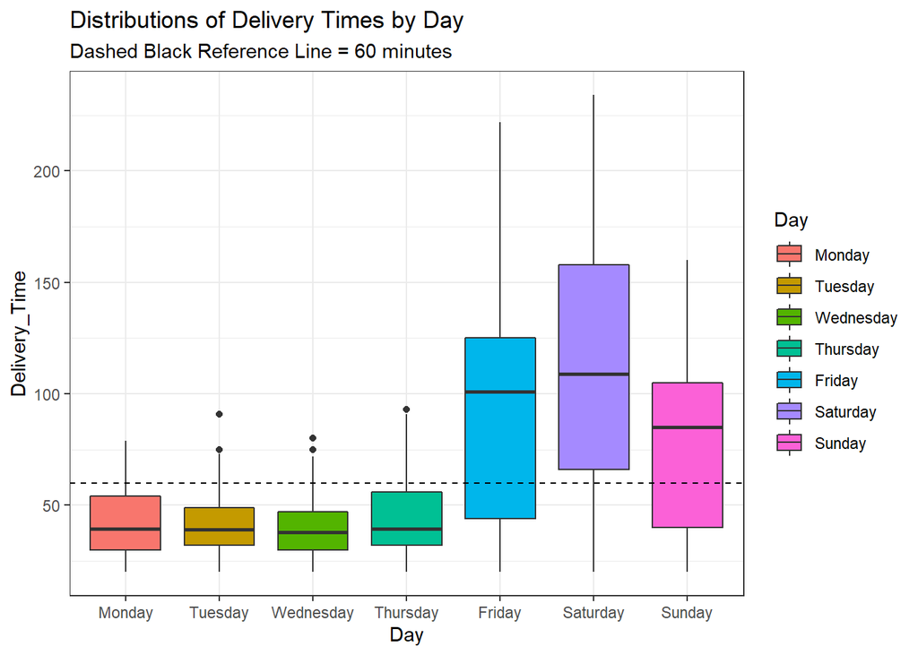

```r
data %>%  drop_na() %>%
          ggplot(.,aes(x=Day, y=Delivery_Time, fill=Day)) +
          geom_boxplot() +
          geom_hline(aes(yintercept=60), color='black', linetype='dashed') +
          ggtitle("Distributions of Delivery Times by Day",
                  subtitle="Dashed Black Reference Line = 60 minutes") +
          theme_bw()
```

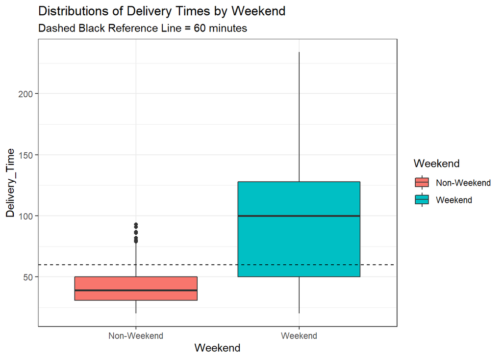

```r
data %>%  drop_na() %>%
          ggplot(.,aes(x=Weekend, y=Delivery_Time, fill=Weekend)) +
          geom_boxplot() +
          geom_hline(aes(yintercept=60), color='black', linetype='dashed') +
          ggtitle("Distributions of Delivery Times by Weekend",
                  subtitle="Dashed Black Reference Line = 60 minutes") +
          theme_bw()
```

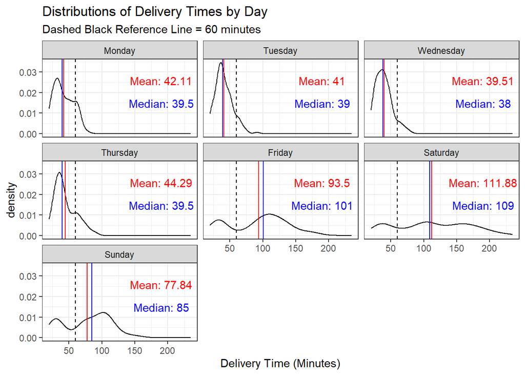

```r
temp <- data %>% group_by(Day) %>%
        summarize(mean_delivery_time = round(mean(Delivery_Time, na.rm=TRUE),2),
                  median_delivery_time=round(median(Delivery_Time, na.rm=TRUE),2))


data %>% drop_na() %>%
          ggplot(.,aes(x=Delivery_Time)) + geom_density() +
          facet_wrap(~Day) +
          theme_bw() +
          labs(x="Delivery Time (Minutes)") +
          geom_vline(aes(xintercept=60), color='black', linetype='dashed') +
          geom_vline(data=temp, aes(xintercept=mean_delivery_time), color='red') +
          geom_vline(data=temp, aes(xintercept=median_delivery_time), color='blue') +
          ggtitle("Distributions of Delivery Times by Day",
                  subtitle="Dashed Black Reference Line = 60 minutes") +
          geom_text(data=temp,aes(x=190, label=paste("Median:",as.character(median_delivery_time)),
                                  y=0.019), colour="blue",vjust = 1.5)+
          geom_text(data=temp,aes(x=190, label=paste("Mean:",as.character(mean_delivery_time)),
                                  y=0.03), colour="red",vjust = 1.5)
```

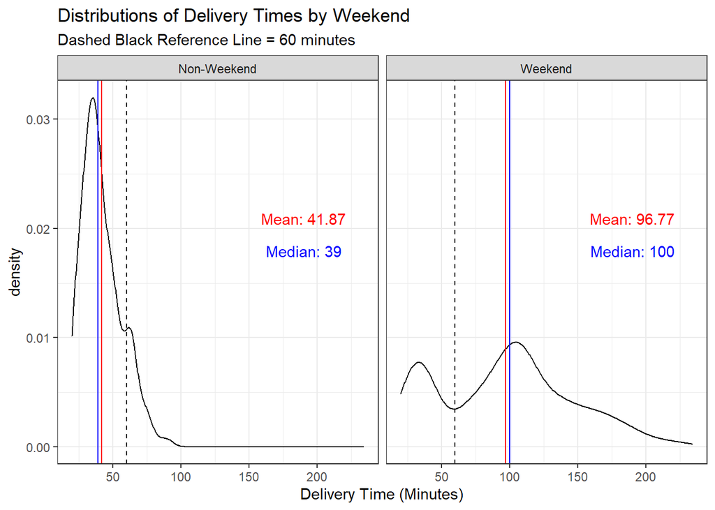

```r
temp <- data %>%  group_by(Weekend) %>%
        summarize(mean_delivery_time = round(mean(Delivery_Time, na.rm=TRUE),2),
                  median_delivery_time=round(median(Delivery_Time, na.rm=TRUE),2))


data %>% drop_na() %>%
          ggplot(.,aes(x=Delivery_Time)) + geom_density() +
          facet_wrap(~Weekend) +
          theme_bw() +
          labs(x="Delivery Time (Minutes)") +
          geom_vline(aes(xintercept=60), color='black', linetype='dashed') +
          geom_vline(data=temp, aes(xintercept=mean_delivery_time), color='red') +
          geom_vline(data=temp, aes(xintercept=median_delivery_time), color='blue') +
          ggtitle("Distributions of Delivery Times by Weekend",
                  subtitle="Dashed Black Reference Line = 60 minutes") +
          geom_text(data=temp,aes(x=190, label=paste("Median:",as.character(median_delivery_time)),
                                  y=0.019), colour="blue",vjust = 1.5)+
          geom_text(data=temp,aes(x=190, label=paste("Mean:",as.character(mean_delivery_time)),
                                  y=0.022), colour="red",vjust = 1.5)
```

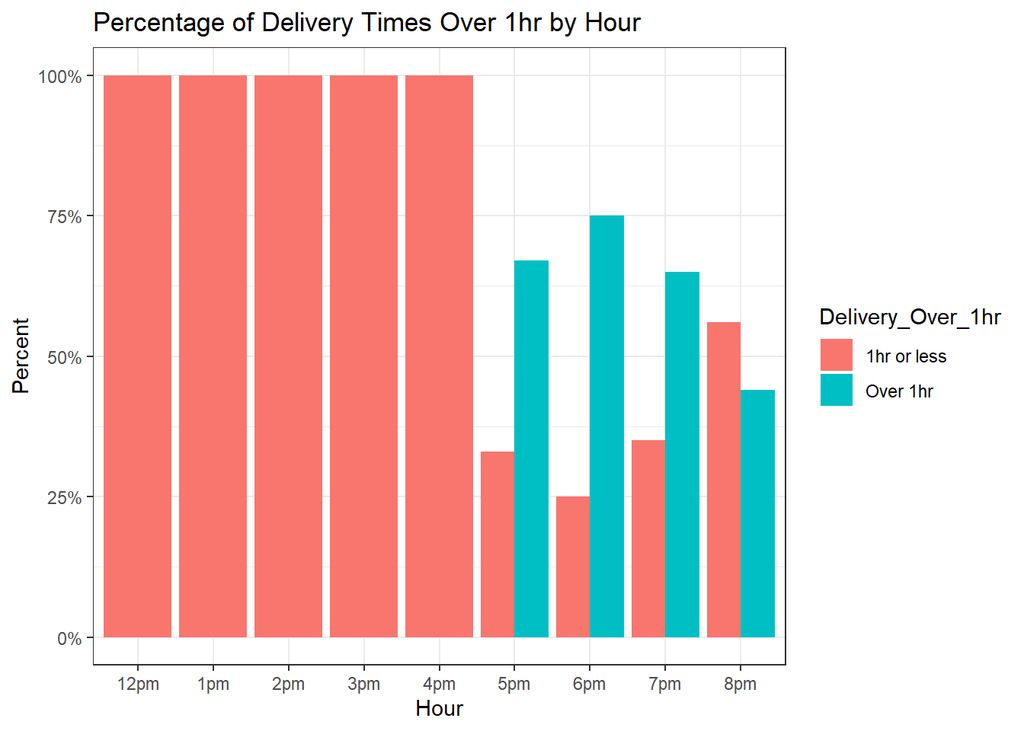

```r
data %>% drop_na() %>%
          group_by(Hour, Delivery_Over_1hr) %>%
          summarize(count=n()) %>%
          mutate(Percent = round(count / sum(count),2)) %>%
          ggplot(., aes(x=Hour,y=Percent, fill=Delivery_Over_1hr)) + geom_col(position = "dodge") +
          scale_y_continuous(labels = function(x) paste0(x*100, "%"), limits = c(0,1)) +
          ggtitle("Percentage of Delivery Times Over 1hr by Hour") +
          theme_bw()
```

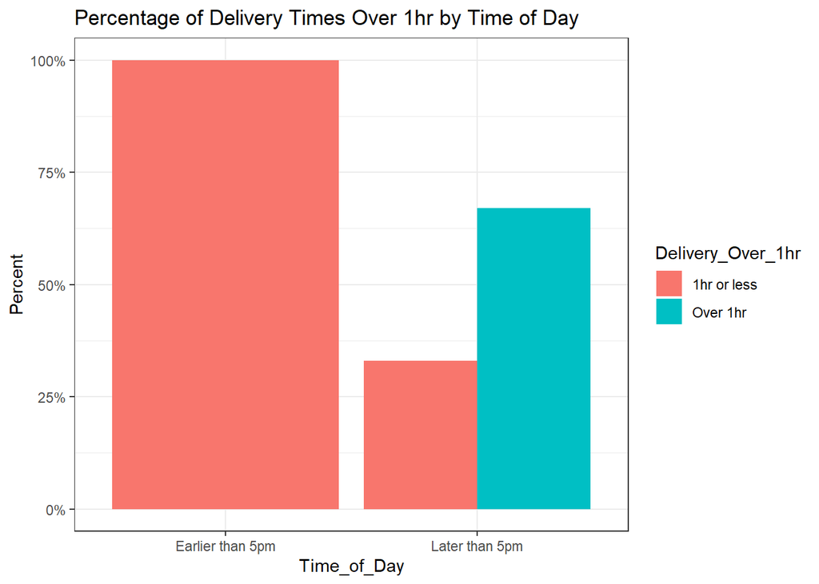

```r
data %>% drop_na() %>%
          group_by(Time_of_Day, Delivery_Over_1hr) %>%
          summarize(count=n()) %>%
          mutate(Percent = round(count / sum(count),2)) %>%
          ggplot(., aes(x=Time_of_Day,y=Percent, fill=Delivery_Over_1hr)) + geom_col(position = "dodge") +
          scale_y_continuous(labels = function(x) paste0(x*100, "%"), limits = c(0,1)) +
          ggtitle("Percentage of Delivery Times Over 1hr by Time of Day") +
          theme_bw()
```

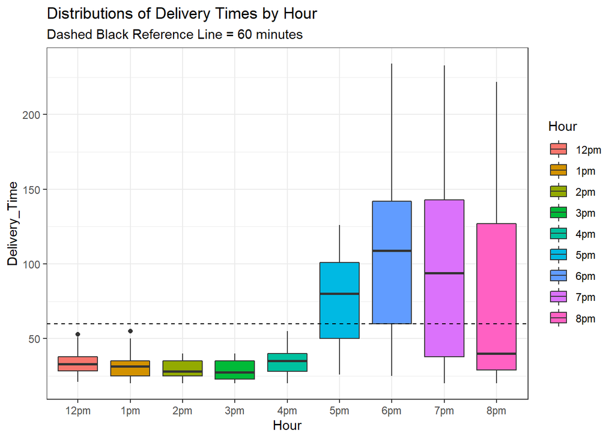

```r
data %>%  drop_na() %>%
          ggplot(.,aes(x=Hour, y=Delivery_Time, fill=Hour)) +
          geom_boxplot() +
          geom_hline(aes(yintercept=60), color='black', linetype='dashed') +
          ggtitle("Distributions of Delivery Times by Hour",
                  subtitle="Dashed Black Reference Line = 60 minutes") +
          theme_bw()
```

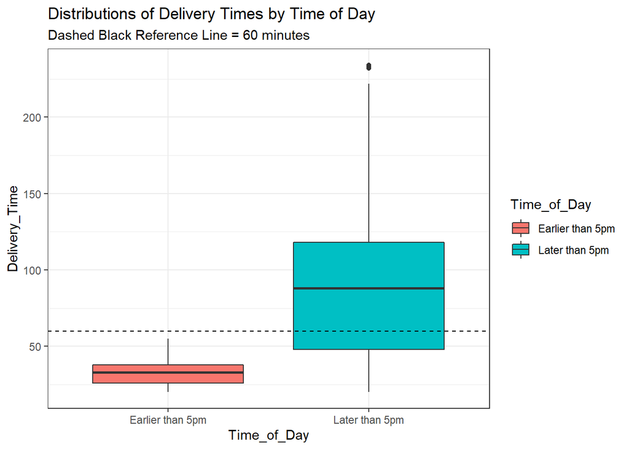

```r
data %>%  drop_na() %>%
          ggplot(.,aes(x=Time_of_Day, y=Delivery_Time, fill=Time_of_Day)) +
          geom_boxplot() +
          geom_hline(aes(yintercept=60), color='black', linetype='dashed') +
          ggtitle("Distributions of Delivery Times by Time of Day",
                  subtitle="Dashed Black Reference Line = 60 minutes") +
          theme_bw()
```

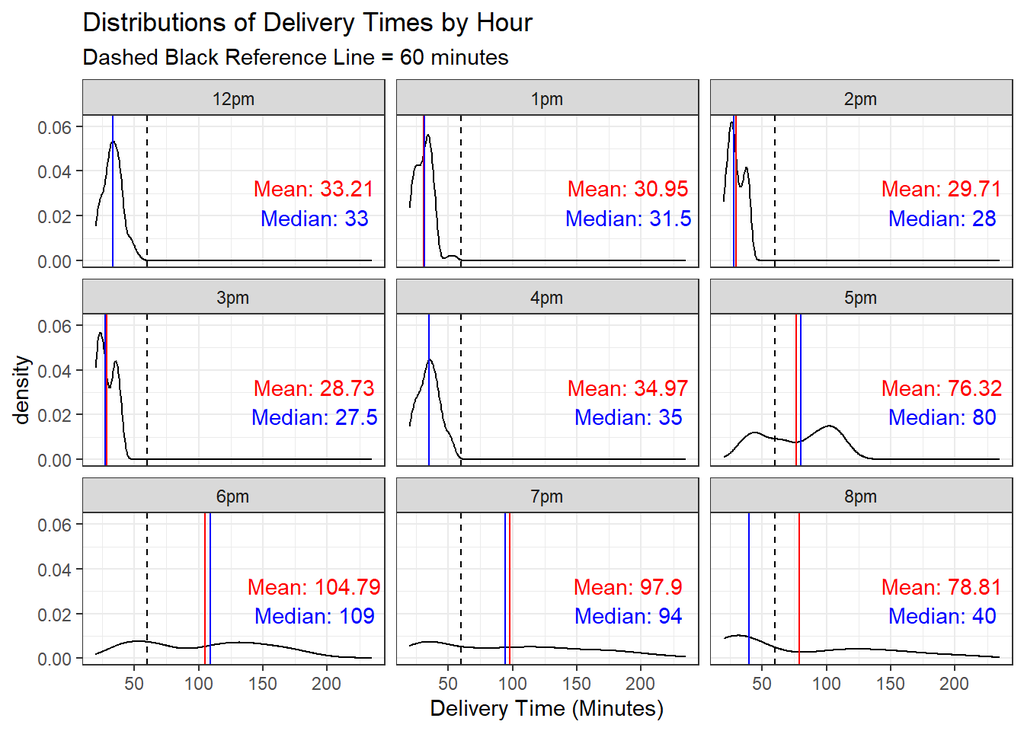

```r
temp <- data %>% group_by(Hour) %>%
        summarize(mean_delivery_time = round(mean(Delivery_Time, na.rm=TRUE),2),
                  median_delivery_time=round(median(Delivery_Time, na.rm=TRUE),2))

data %>% drop_na() %>%
          ggplot(.,aes(x=Delivery_Time)) + geom_density() +
          facet_wrap(~Hour) +
          theme_bw() +
          labs(x="Delivery Time (Minutes)") +
          geom_vline(aes(xintercept=60), color='black', linetype='dashed') +
          geom_vline(data=temp, aes(xintercept=mean_delivery_time), color='red') +
          geom_vline(data=temp, aes(xintercept=median_delivery_time), color='blue') +
          ggtitle("Distributions of Delivery Times by Hour",
                  subtitle="Dashed Black Reference Line = 60 minutes") +
          geom_text(data=temp, aes(x=190, label=paste("Median:",as.character(median_delivery_time)),
                                   y=0.027), colour="blue",vjust = 1.5)+
          geom_text(data=temp, aes(x=190, label=paste("Mean:",as.character(mean_delivery_time)),
                                   y=0.04), colour="red",vjust = 1.5)
```

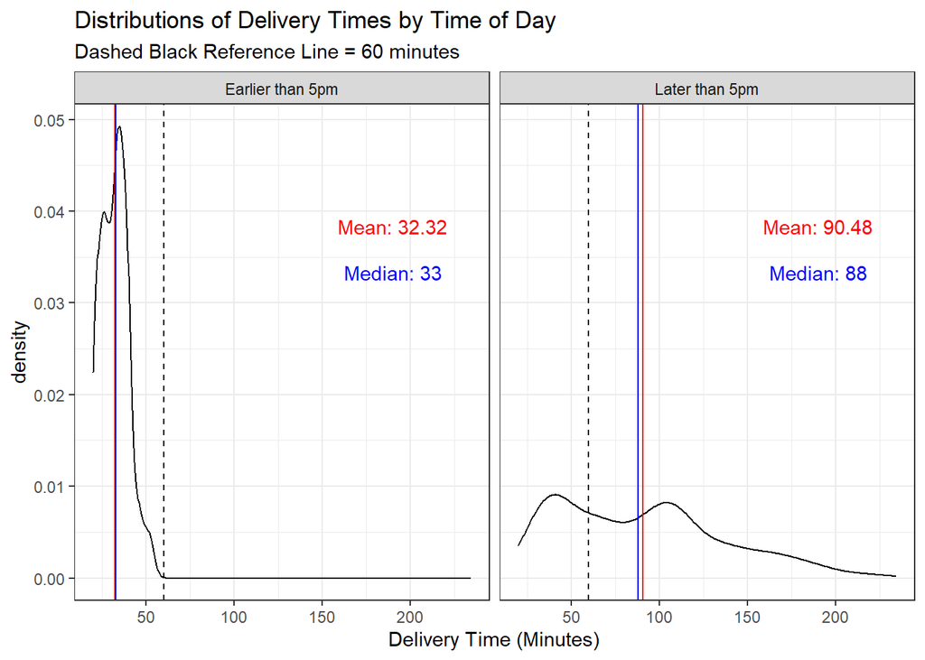

```r
temp <- data %>% group_by(Time_of_Day) %>%
        summarize(mean_delivery_time = round(mean(Delivery_Time, na.rm=TRUE),2),
                  median_delivery_time=round(median(Delivery_Time, na.rm=TRUE),2))

data %>% drop_na() %>%
          ggplot(.,aes(x=Delivery_Time)) + geom_density() +
          facet_wrap(~Time_of_Day) +
          theme_bw() +
          labs(x="Delivery Time (Minutes)") +
          geom_vline(aes(xintercept=60), color='black', linetype='dashed') +
          geom_vline(data=temp, aes(xintercept=mean_delivery_time), color='red') +
          geom_vline(data=temp, aes(xintercept=median_delivery_time), color='blue') +
          ggtitle("Distributions of Delivery Times by Time of Day",
                  subtitle="Dashed Black Reference Line = 60 minutes") +
          geom_text(data=temp, aes(x=190, label=paste("Median:",as.character(median_delivery_time)),
                                   y=0.035), colour="blue",vjust = 1.5)+
          geom_text(data=temp, aes(x=190, label=paste("Mean:",as.character(mean_delivery_time)),
                                   y=0.04), colour="red",vjust = 1.5)
```

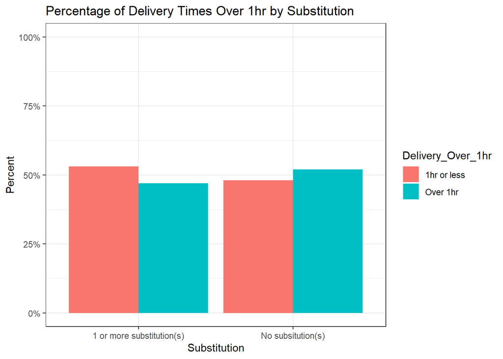

```r
data %>% drop_na() %>%
          group_by(Substitution, Delivery_Over_1hr) %>%
          summarize(count=n()) %>%
          mutate(Percent = round(count / sum(count),2)) %>%
          ggplot(., aes(x=Substitution,y=Percent, fill=Delivery_Over_1hr)) + geom_col(position = "dodge") +
          scale_y_continuous(labels = function(x) paste0(x*100, "%"), limits = c(0,1)) +
          ggtitle("Percentage of Delivery Times Over 1hr by Substitution") +
          theme_bw()
```

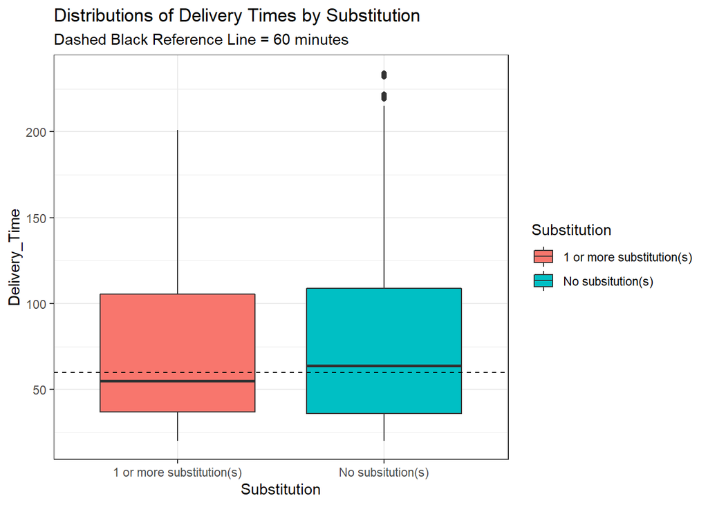

```r
data %>%  drop_na() %>%
          ggplot(.,aes(x=Substitution, y=Delivery_Time, fill=Substitution)) +
          geom_boxplot() +
          geom_hline(aes(yintercept=60), color='black', linetype='dashed') +
          ggtitle("Distributions of Delivery Times by Substitution",
                  subtitle="Dashed Black Reference Line = 60 minutes") +
          theme_bw()
```

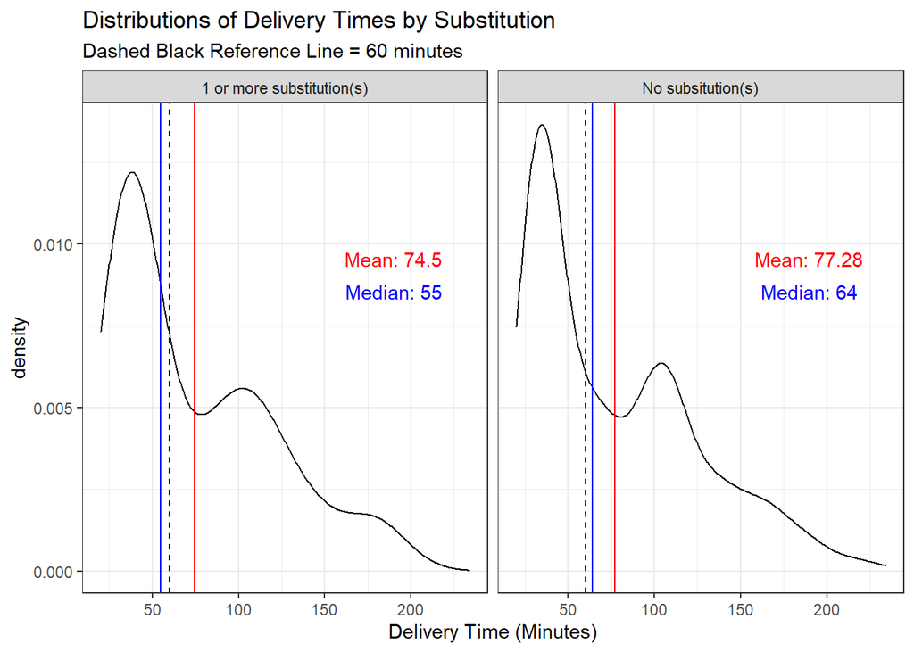

```r
temp <- data %>% group_by(Substitution) %>%
        summarize(mean_delivery_time = round(mean(Delivery_Time, na.rm=TRUE),2),
                  median_delivery_time=round(median(Delivery_Time, na.rm=TRUE),2))

data %>% drop_na() %>%
          ggplot(.,aes(x=Delivery_Time)) + geom_density() +
          facet_wrap(~Substitution) +
          theme_bw() +
          labs(x="Delivery Time (Minutes)") +
          geom_vline(aes(xintercept=60), color='black', linetype='dashed') +
          geom_vline(data=temp, aes(xintercept=mean_delivery_time), color='red') +
          geom_vline(data=temp, aes(xintercept=median_delivery_time), color='blue') +
          ggtitle("Distributions of Delivery Times by Substitution",
                  subtitle="Dashed Black Reference Line = 60 minutes") +
          geom_text(data=temp, aes(x=190, label=paste("Median:",as.character(median_delivery_time)),
                                   y=0.009), colour="blue",vjust = 1.5)+
          geom_text(data=temp, aes(x=190, label=paste("Mean:",as.character(mean_delivery_time)),
                                   y=0.010), colour="red",vjust = 1.5)
```

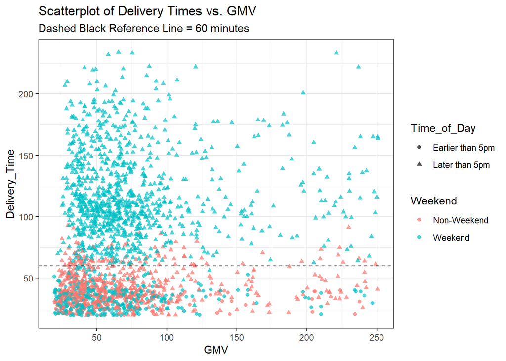

```r
data %>% drop_na() %>%
        ggplot(., aes(x=GMV,y=Delivery_Time, shape=Time_of_Day, color=Weekend)) +
               geom_jitter(alpha=0.7) +
               geom_hline(aes(yintercept=60), color='black', linetype='dashed') +
               ggtitle("Scatterplot of Delivery Times vs. GMV",
                  subtitle="Dashed Black Reference Line = 60 minutes") +
               theme_bw()
```

Similar to voided orders, the above visualizations show that orders where delivery times were higher tended to be after 5pm on weekends. Also, the stores seem to have varying distributions of delivery times, with Store A being the slowest and Store C the quickest.

Let’s visually explore the interaction between the *Weekend/Time_of_Day* and this relationship to *Delivery_Time*/*Delivery_Over_1hr*. From the figures below, it’s clear that orders placed after 5pm on weekends had a higher probability of having a delivery time over 1 hour. Regardless of the day, any orders placed before 5pm were delivered within an hour.

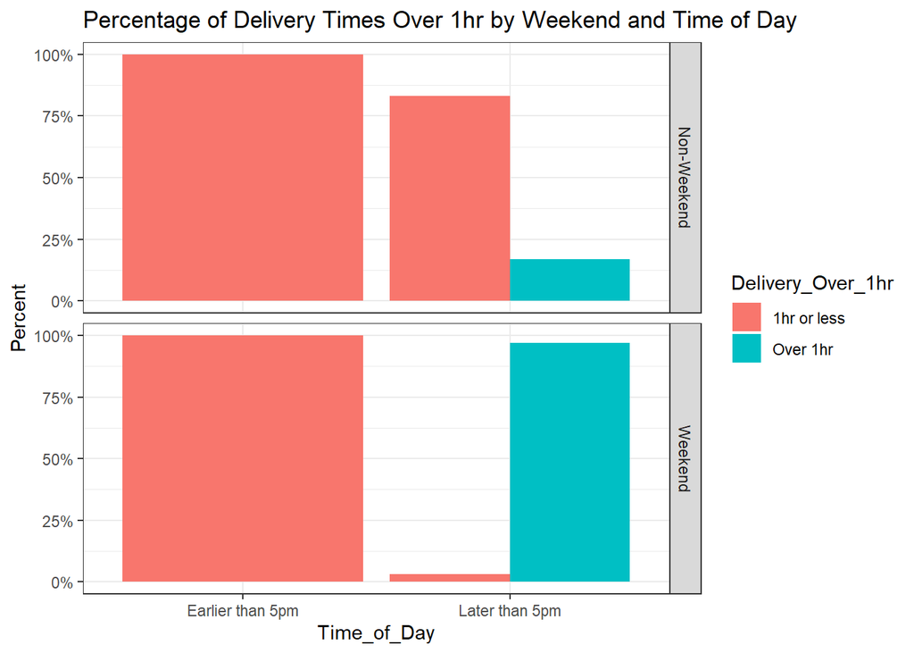

```r
data %>% drop_na() %>%
         group_by(Weekend, Time_of_Day, Delivery_Over_1hr) %>%
         summarize(count=n()) %>%
         mutate(Percent = round(count/sum(count),2)) %>%
         ggplot(., aes(x=Time_of_Day,y=Percent, fill=Delivery_Over_1hr)) + geom_col(position = "dodge") +
               scale_y_continuous(labels = function(x) paste0(x*100, "%")) +
               ggtitle("Percentage of Delivery Times Over 1hr by Weekend and Time of Day") +
               facet_grid(rows= vars(Weekend)) +
               theme_bw()
```

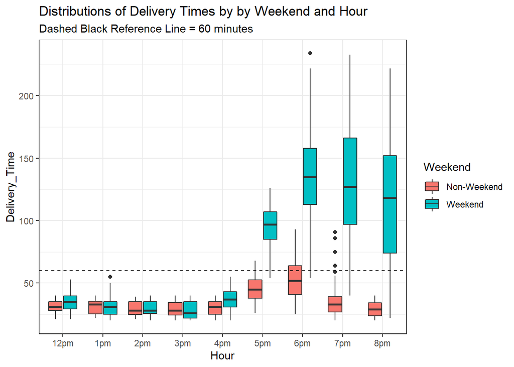

```r
data %>%  drop_na() %>%
          ggplot(.,aes(x=Hour, y=Delivery_Time, fill=Weekend)) +
          geom_boxplot() +
          geom_hline(aes(yintercept=60), color='black', linetype='dashed') +
          ggtitle("Distributions of Delivery Times by by Weekend and Hour",
                  subtitle="Dashed Black Reference Line = 60 minutes") +
          theme_bw()
```

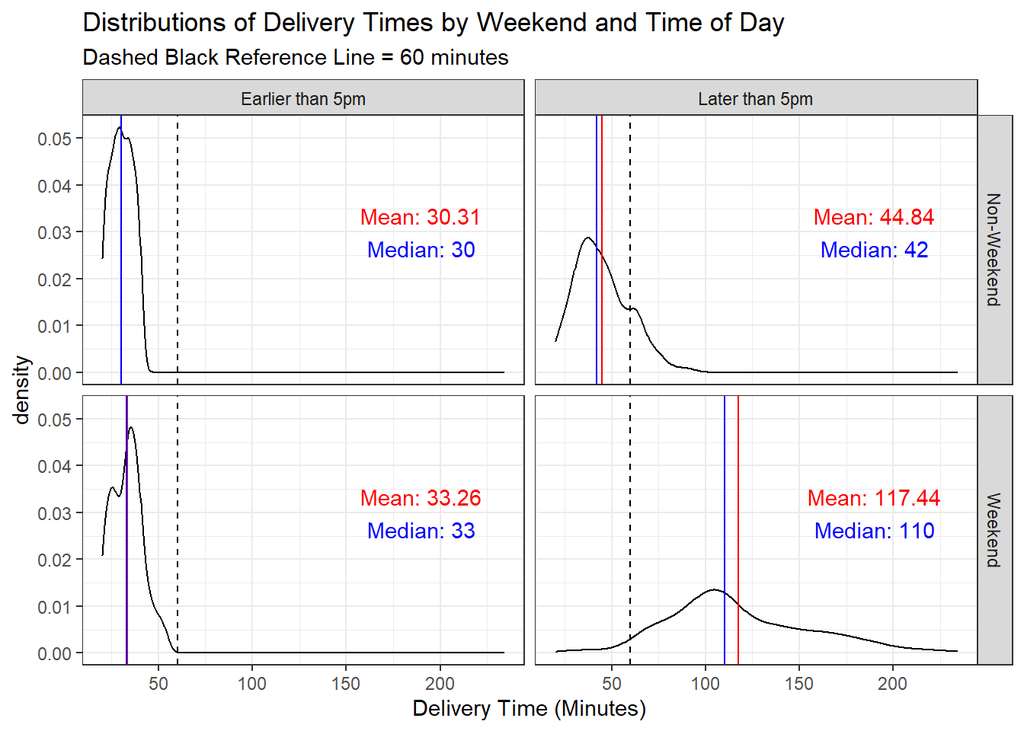

```r
temp <- data %>% group_by(Weekend, Time_of_Day) %>%
        summarize(mean_delivery_time = round(mean(Delivery_Time, na.rm=TRUE),2),
                  median_delivery_time=round(median(Delivery_Time, na.rm=TRUE),2))

data %>% drop_na() %>%
          ggplot(.,aes(x=Delivery_Time)) + geom_density() +
          facet_grid(rows=vars(Weekend), cols=vars(Time_of_Day)) +
          theme_bw() +
          labs(x="Delivery Time (Minutes)") +
          geom_vline(aes(xintercept=60), color='black', linetype='dashed') +
          geom_vline(data=temp, aes(xintercept=mean_delivery_time), color='red') +
          geom_vline(data=temp, aes(xintercept=median_delivery_time), color='blue') +
          ggtitle("Distributions of Delivery Times by Weekend and Time of Day",
                  subtitle="Dashed Black Reference Line = 60 minutes") +
          geom_text(data=temp, aes(x=190, label=paste("Median:",as.character(median_delivery_time)),
                                   y=0.03), colour="blue",vjust = 1.5)+
          geom_text(data=temp, aes(x=190, label=paste("Mean:",as.character(mean_delivery_time)),
                                   y=0.037), colour="red",vjust = 1.5)
```

From the exploratory data analysis, it’s clear that orders placed on weekends after 5pm are the biggest contributors to both orders being voided and delivery times taking longer than 1 hour. From a business standpoint, this information is valuable as it shows where adjustments can be made to reduce voids and longer delivery times.

For the purposes of this project, the majority of possible potential business solutions will not be discussed in detail. One solution that will be discussed is tackling the delivery time problem by attempting to accurately predict delivery times, so that even if deliveries take longer than one hour at least an approximate time can be given to customers. This solution is discussed in the section below.

### 4) Predicting Delivery Times

First, training and validation datasets are created. The training set consists of 70% of the data and the validation set consists of 30% of the data. A partition is created so that both the training and validation sets have an equal proportion of observations where the delivery time was over 1 hour.

```r
set.seed(2)

temp <- data %>% drop_na() %>%
                       select(Delivery_Time, Delivery_Over_1hr, Weekend, Store, Day, Hour,
                              Time_of_Day, GMV, Substitution)

index = createDataPartition(temp$Delivery_Over_1hr, p = 0.70, list = FALSE)
data_train = temp[index, ]
data_val = temp[-index, ]
```

Next, to check that the split was made appropriately. This is especially important because the data was split on a binary feature and the outcome being looked at is continuous. Based on the similar overlying density plots and mean delivery times for both of the datasets, an appropriate split was completed.

```r
mean(data_train$Delivery_Time)
```

```
## [1] 77.15763
```

```r
mean(data_val$Delivery_Time)
```

```
## [1] 76.81333
```

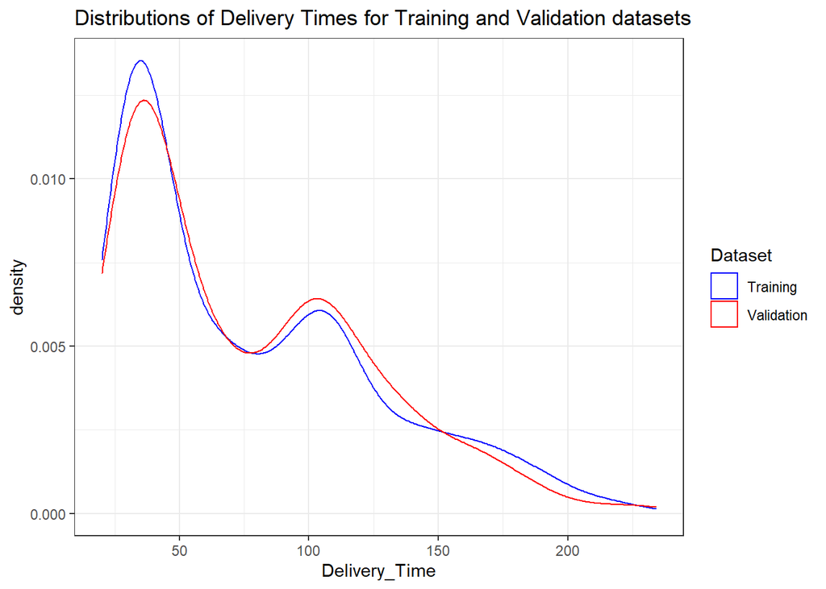

```r
ggplot(data_train) + geom_density(data=data_train, aes(x=Delivery_Time, col='blue')) +
                     geom_density(data=data_val, aes(x=Delivery_Time, col='red')) +
                     theme_bw() +
                     scale_color_manual(labels = c("Training", "Validation"), values = c("blue", "red")) +
                     guides(color=guide_legend("Dataset")) +
                     ggtitle("Distributions of Delivery Times for Training and Validation datasets")
```

Now, a linear regression model is created to predict **Delivery_Time** using **Store, Day, Hour, GMV**, and **Substitution**. The model also includes a 3-way interaction term between **Day/Hour/Store**. This interaction term was included based on the EDA.

The model below has an Adj. R<sup>2</sup> of 0.897 compared to the Adj. R<sup>2</sup> of 0.693 for the simpler model with no interaction terms (the output of this model is not shown).

```r
model <- lm(Delivery_Time ~ Store +
                            Substitution +
                            Day  +
                            Hour +
                            GMV +
                            Day:Hour:Store,
                            data=data_train)

summ(model, digits=3, confint = TRUE)
```

| Observations | 1402 |
| --- | --- |
| Dependent variable | Delivery_Time |
| Type | OLS linear regression |

| F(184,1217) | 67.462 |
| --- | --- |
| R² | 0.911 |
| Adj. R² | 0.897 |

|  | Est. | 2.5% | 97.5% | t val. | p |
| --- | --- | --- | --- | --- | --- |
| (Intercept) | 37.672 | -15.688 | 91.032 | 1.385 | 0.166 |
| StoreStore B | -12.023 | -33.200 | 9.153 | -1.114 | 0.266 |
| StoreStore C | -11.607 | -36.274 | 13.060 | -0.923 | 0.356 |
| SubstitutionNo subsitution(s) | -0.888 | -4.239 | 2.463 | -0.520 | 0.603 |
| DayTuesday | 4.753 | -32.837 | 42.344 | 0.248 | 0.804 |
| DayWednesday | -3.385 | -41.002 | 34.231 | -0.177 | 0.860 |
| DayThursday | 0.336 | -27.728 | 28.400 | 0.023 | 0.981 |
| DayFriday | 85.794 | 59.207 | 112.381 | 6.331 | 0.000 |
| DaySaturday | 91.828 | 65.231 | 118.424 | 6.774 | 0.000 |
| DaySunday | 3.256 | -27.477 | 33.989 | 0.208 | 0.835 |
| Hour1pm | 2.399 | -22.659 | 27.456 | 0.188 | 0.851 |
| Hour2pm | 10.550 | -17.515 | 38.614 | 0.737 | 0.461 |
| Hour3pm | -7.269 | -42.711 | 28.173 | -0.402 | 0.687 |
| Hour4pm | 3.164 | -18.539 | 24.868 | 0.286 | 0.775 |
| Hour5pm | 64.915 | 46.262 | 83.568 | 6.828 | 0.000 |
| Hour6pm | 60.735 | 41.847 | 79.623 | 6.309 | 0.000 |
| Hour7pm | 40.953 | 21.141 | 60.764 | 4.056 | 0.000 |
| Hour8pm | 2.469 | -25.604 | 30.541 | 0.173 | 0.863 |
| GMV | -0.008 | -0.027 | 0.012 | -0.785 | 0.433 |
| StoreStore A:DayMonday:Hour12pm | -6.370 | -61.594 | 48.855 | -0.226 | 0.821 |
| StoreStore B:DayMonday:Hour12pm | 5.691 | -51.841 | 63.223 | 0.194 | 0.846 |
| StoreStore C:DayMonday:Hour12pm | 6.504 | -40.410 | 53.417 | 0.272 | 0.786 |
| StoreStore A:DayTuesday:Hour12pm | -10.078 | -70.109 | 49.953 | -0.329 | 0.742 |
| StoreStore B:DayTuesday:Hour12pm | 3.187 | -58.291 | 64.665 | 0.102 | 0.919 |
| StoreStore C:DayTuesday:Hour12pm | -4.114 | -51.023 | 42.795 | -0.172 | 0.863 |
| StoreStore A:DayWednesday:Hour12pm | -5.449 | -66.736 | 55.838 | -0.174 | 0.862 |
| StoreStore B:DayWednesday:Hour12pm | 10.713 | -55.670 | 77.095 | 0.317 | 0.752 |
| StoreStore C:DayWednesday:Hour12pm | 19.074 | -32.837 | 70.985 | 0.721 | 0.471 |
| StoreStore A:DayThursday:Hour12pm | -3.139 | -56.042 | 49.763 | -0.116 | 0.907 |
| StoreStore B:DayThursday:Hour12pm | 8.751 | -48.766 | 66.269 | 0.299 | 0.765 |

[output cut: 178 more lines]

Standard errors: OLS

The above model is utilized to predict delivery times for both the training and validation datasets. Next, the **mean absolute error (MAE)** for predicted delivery times is calculated for both datasets.

- **Training MAE**: 10.29 minutes
- **Validation MAE**: 10.89 minutes

```r
preds = predict(model, newdata=data_train)

data_train %>% select(Delivery_Time) %>%
               rename(Actual_Time=Delivery_Time) %>%
               mutate(Predicted_Time = preds) %>%
               mutate(abs_error=abs(Actual_Time-Predicted_Time)) %>%
               summarize(Mean_Absolute_Error_Train=mean(abs_error))
```

```
## # A tibble: 1 x 1
##   Mean_Absolute_Error_Train
##                       <dbl>
## 1                      10.3
```

```r
preds = predict(model, newdata=data_val)

data_val %>% select(Delivery_Time) %>%
               rename(Actual_Time=Delivery_Time) %>%
               mutate(Predicted_Time = preds) %>%
               mutate(abs_error=abs(Actual_Time-Predicted_Time)) %>%
               summarize(Mean_Absolute_Error_Val=mean(abs_error))
```

```
## # A tibble: 1 x 1
##   Mean_Absolute_Error_Val
##                     <dbl>
## 1                    10.9
```

The fact that the MAE for the validation set is similar to the training set supports the idea that the model did not overfit on the training data.